# HW2 Regression Analysis

#### Модель с преобразованными данными

```r
model_bcnva <- lm(bcnva_log ~ strat + bcdva_log + age_flwp, data = df)
print(vif(model_bcnva))
```

```
##     strat bcdva_log  age_flwp
##  1.245408  1.139786  1.222278
```

```r
model_bcdva <- lm(bcdva_log ~ strat + bcnva_log + age_flwp + side, data = df)
print(vif(model_bcdva))
```

```
##     strat bcnva_log  age_flwp      side
##  1.131698  1.002256  1.134613  1.005470
```

```r
#Включаю логарифмированные значения
```

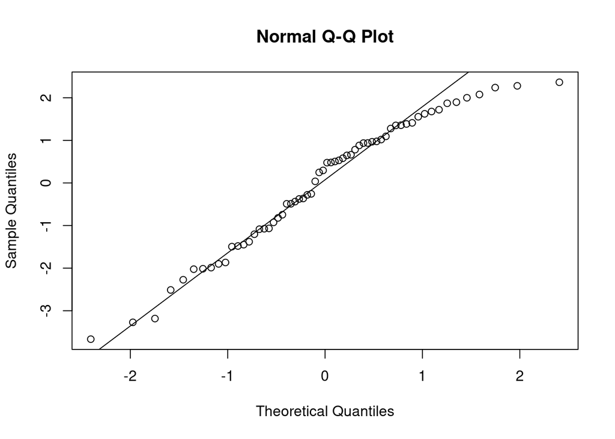

```r
qqnorm(residuals(model_bcnva))
qqline(residuals(model_bcnva))
```

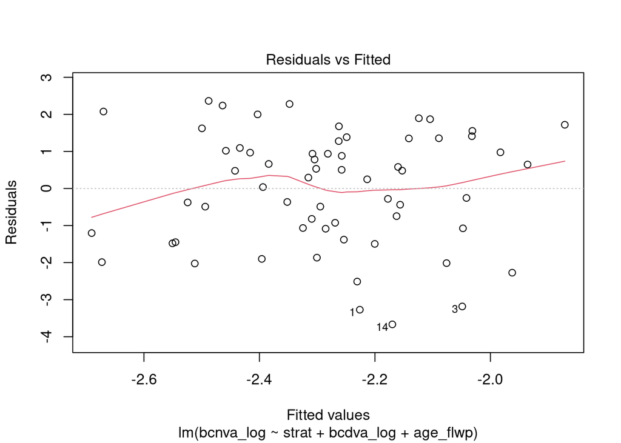

```r
plot(model_bcnva, which = 1)
```

```r
print(bptest(model_bcnva))
```

```
##
##  studentized Breusch-Pagan test
##
## data:  model_bcnva
## BP = 1.1416, df = 3, p-value = 0.767
```

```r
print(shapiro.test(residuals(model_bcnva)))
```

```
##
##  Shapiro-Wilk normality test
##
## data:  residuals(model_bcnva)
## W = 0.95956, p-value = 0.03939
```

```r
# Как и в случае распределения переменной, тест Шапиро-Уилка все еще показывает отклонение остатков от нормальности. Но если мы сделаем отсечку менее строгой, например 0.01, учитывая большую чувствительность теста, и примем во внимание достаточно адекватные графические результаты, то, думаю, можно считать модель рабочей
```

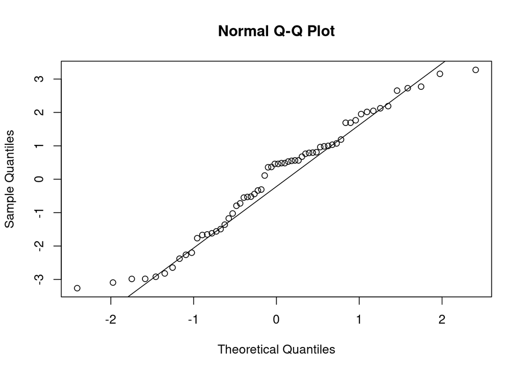

```r
qqnorm(residuals(model_bcdva))
qqline(residuals(model_bcdva))
```

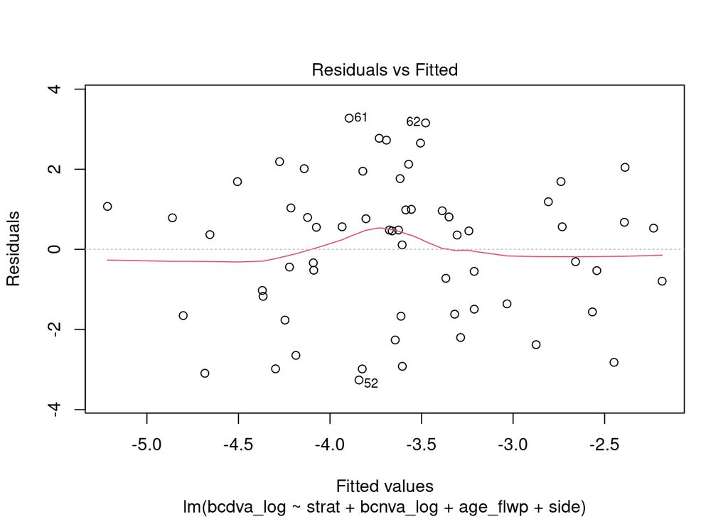

```r
plot(model_bcdva, which = 1)
```

```r
print(bptest(model_bcdva))
```

```
##
##  studentized Breusch-Pagan test
##
## data:  model_bcdva
## BP = 2.5739, df = 4, p-value = 0.6315
```

```r
print(shapiro.test(residuals(model_bcdva)))
```

```
##
##  Shapiro-Wilk normality test
##
## data:  residuals(model_bcdva)
## W = 0.96583, p-value = 0.0817
```

```r
# У bcdva все хорошо по гомоскедастичности и нормальности остатков на уровне 0.05
```

```r
summary(model_bcdva)
```

```
##
## Call:
## lm(formula = bcdva_log ~ strat + bcnva_log + age_flwp + side,
##     data = df)
##
## Residuals:
##     Min      1Q  Median      3Q     Max
## -3.2617 -1.4599  0.4599  1.0252  3.2742
##
## Coefficients:
##                 Estimate Std. Error t value Pr(>|t|)
## (Intercept)     -1.97195    0.98233  -2.007   0.0495 *
## stratArtephakia  1.20062    0.49568   2.422   0.0186 *
## bcnva_log        0.12783    0.14995   0.852   0.3975
## age_flwp        -0.16796    0.07565  -2.220   0.0304 *
## sideR           -0.19827    0.46225  -0.429   0.6696
## ---
## Signif. codes:  0 '***' 0.001 '**' 0.01 '*' 0.05 '.' 0.1 ' ' 1
##
## Residual standard error: 1.8 on 57 degrees of freedom
## Multiple R-squared:  0.1363, Adjusted R-squared:  0.0757
## F-statistic: 2.249 on 4 and 57 DF,  p-value: 0.07501
```

```r
anova(model_bcdva)
```

```
## Analysis of Variance Table
##
## Response: bcdva_log
##           Df  Sum Sq Mean Sq F value  Pr(>F)
## strat      1  10.659 10.6586  3.2906 0.07494 .
## bcnva_log  1   2.278  2.2777  0.7032 0.40521
## age_flwp   1  15.605 15.6053  4.8178 0.03226 *
## side       1   0.596  0.5959  0.1840 0.66959
## Residuals 57 184.629  3.2391
## ---
## Signif. codes:  0 '***' 0.001 '**' 0.01 '*' 0.05 '.' 0.1 ' ' 1
```

```r
summary(model_bcnva)
```

```
##
## Call:
## lm(formula = bcnva_log ~ strat + bcdva_log + age_flwp, data = df)
##
## Residuals:
##     Min      1Q  Median      3Q     Max
## -3.6670 -1.0831  0.3856  1.2316  2.3631
##
## Coefficients:
##                 Estimate Std. Error t value Pr(>|t|)
## (Intercept)     -2.14899    0.79543  -2.702  0.00903 **
## stratArtephakia  0.01936    0.45253   0.043  0.96603
## bcdva_log        0.09758    0.11437   0.853  0.39705
## age_flwp         0.01811    0.06833   0.265  0.79189
## ---
## Signif. codes:  0 '***' 0.001 '**' 0.01 '*' 0.05 '.' 0.1 ' ' 1
##
## Residual standard error: 1.566 on 58 degrees of freedom
## Multiple R-squared:  0.01447,    Adjusted R-squared:  -0.03651
## F-statistic: 0.2838 on 3 and 58 DF,  p-value: 0.8369
```

```r
anova(model_bcnva)
```

```
## Analysis of Variance Table
##
## Response: bcnva_log
##           Df  Sum Sq Mean Sq F value Pr(>F)
## strat      1   0.301 0.30066  0.1226 0.7275
## bcdva_log  1   1.616 1.61572  0.6586 0.4204
## age_flwp   1   0.172 0.17239  0.0703 0.7919
## Residuals 58 142.286 2.45321
```

#### Анализ результатов моделирования

*Острота вдали.* 1. Качество модели. Модель отвечает предположениям о распределениях остатков, однако способность модели объяснить переменную низкая, объяснено всего 13.63% вариации зависимой переменной (а скорректированно на признаки - 7.57%). 2. Стратегия лечения “Артефакия” значимо связана с увеличением логарифмированной остроты зрения вдали по сравнению со стратегией “Афакия” (базовый уровень), p=0.02. Это подтверждается ANOVA на уровне значимости 0.1 (p=0.08), что допустимо учитывая не очень большую выборку. 3. С возрастом логарифмированная острота зрения вдали уменьшается, p=0.03, что также подтверждается ановой (p=0.03). 4. Убедительной взаимосвязи между логарифмированной остротой зрения вблизи и вдали, а также между сторонами поражения нет. Однако добавление этих признаков в модель говорит о независимости от них результата со стратегией лечения.

*Острота вблизи* 1. Качество модели. Модель отвечает предположениям о распределениях остатков, но объясняет лишь 1.447% вариации зависимой переменной, а после корректировки на количество предикторов даже показывает отрицательный результат (-3.651%). Это указывает на то, что модель не эффективна для объяснения изменений в остроте зрения вблизи. 2. Ни один из рассмотренных предикторов (стратегия лечения, острота зрения вдали и возраст) не оказывает значимого влияния на остроту зрения вблизи. Модель не показывает хорошей способности объяснить изменения в остроте зрения вблизи на основе этих переменных.

В обоих случаях, значения перехвата оказались значимыми, т.к. остроты зрения при отсутствии влияния всех изучаемых факторов имеют определенное базовое значение отличное от 0.

## 2. Какой эффект оказывает глаукома на остроту зрения? Зависит ли этот эффект от выбранной стратегии? Опишите эффект от терапии с учетом потенциального развития глаукомы. Какая терапия предпочтительнее с учетом потенциального развития глаукомы?

```r
df <- data %>%mutate('bcnva_log'=log(bcnva),'bcdva_log'=log(bcdva),)
head(df)
```

```
##   X  id age_flwp      strat side glau      bcdva      bcnva  bcnva_log
## 1 1 778     10.9    Aphakia    L   No 0.14216528 0.02212973 -3.8108335
## 2 2 606     17.0 Artephakia    L  Yes 0.04645876 0.08051762 -2.5192792
## 3 3 229     15.7 Artephakia    R   No 0.23553021 0.02660241 -3.6267534
## 4 4 553      8.6 Artephakia    L   No 0.48407732 0.05870880 -2.8351657
## 5 5 722      8.5    Aphakia    L   No 0.11316888 0.29293390 -1.2278083
## 6 6 380     15.3 Artephakia    L   No 0.55370578 0.40931418 -0.8932722
##    bcdva_log
## 1 -1.9507649
## 2 -3.0691902
## 3 -1.4459161
## 4 -0.7255106
## 5 -2.1788740
## 6 -0.5911218
```

### 2.1. Оцените эффект без коррекции на ковариаты.

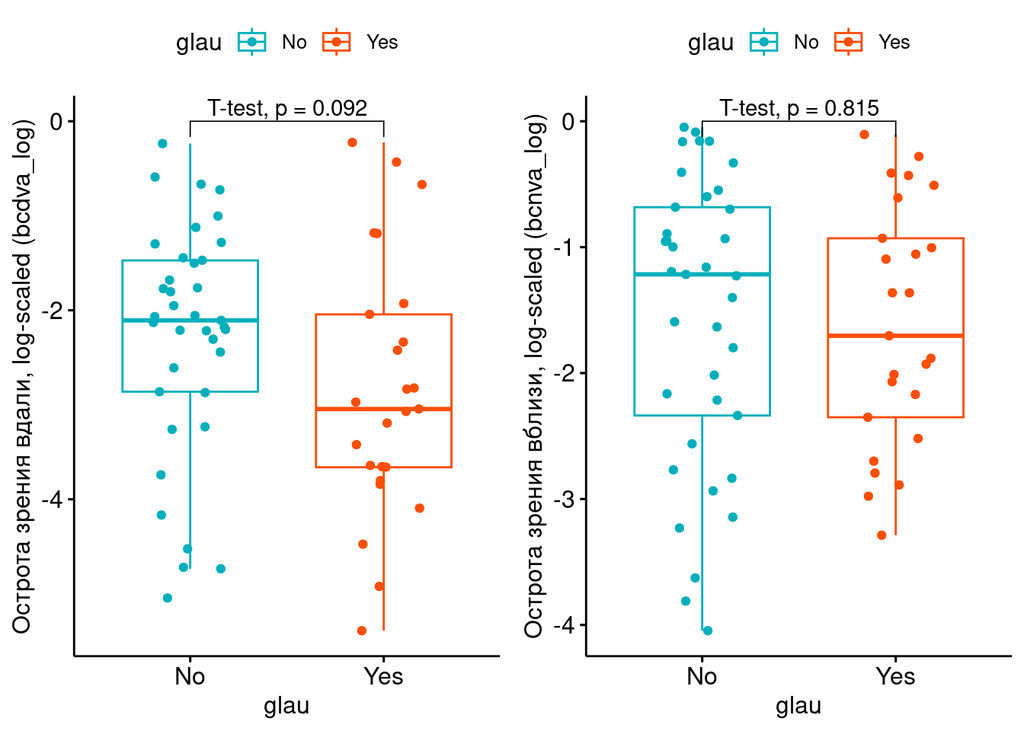

```r
p_bcdva <- ggboxplot(df, x = "glau", y = "bcdva_log", color='glau', palette =c("#00AFBB", "#FC4E07"), ylab = 'Острота зрения вдали, log-scaled (bcdva_log)',  add = "jitter"
)+stat_pvalue_manual(df %>%
  t_test(bcdva_log ~ glau, paired = FALSE), label = "T-test, p = {p}",
                      y.position = 0)
p_bcnva <- ggboxplot(df, x = "glau", y = "bcnva_log",color='glau', palette =c("#00AFBB", "#FC4E07"), ylab = 'Острота зрения вблизи, log-scaled (bcnva_log)',  add = "jitter"
)+stat_pvalue_manual(df %>%
  t_test(bcnva_log ~ glau, paired = FALSE), label = "T-test, p = {p}",
                      y.position = 0)
grid.arrange(p_bcdva, p_bcnva, ncol = 2)
```

```r
# Для остроты в вблизи при отсутствии глаукомы острота вдали выше, для остроты вблизи отличий нет
```

### 2.2. Оцените эффект с коррекцией на ковариаты. Обоснуйте необходимость включения каждой ковариаты в вашу модель.

```r
model_bcnva <- lm(bcnva_log ~ strat + bcdva_log + age_flwp+glau, data = df)
print(vif(model_bcnva))
```

```
##     strat bcdva_log  age_flwp      glau
##  1.246122  1.202617  1.245024  1.078502
```

```r
model_bcdva <- lm(bcdva_log ~ strat + bcnva_log + age_flwp + side+glau, data = df)
print(vif(model_bcdva))
```

```
##     strat bcnva_log  age_flwp      side      glau
##  1.141862  1.002759  1.141526  1.011756  1.029104
```

```r
#Включаю логарифмированные значения как лучше воспринимаемые моделью. Стратегию оставляю, т.к. распределение глаукомы неравномерно по ней и мы знаем, что она незначительно влияет на остроту. Другой вид остроты беру, поскольку остроты могут быть связаны в афакии и при этом стратегии лечения распределены по признаку глаукомы неодинаково. Возраст на фоллоу-ап свзяан и с остротой и с глаукомой. Стороны в обоих случаях связаны с глаукомой визуально, но при этом с остротой стороны связаны только для остроты вдали.
```

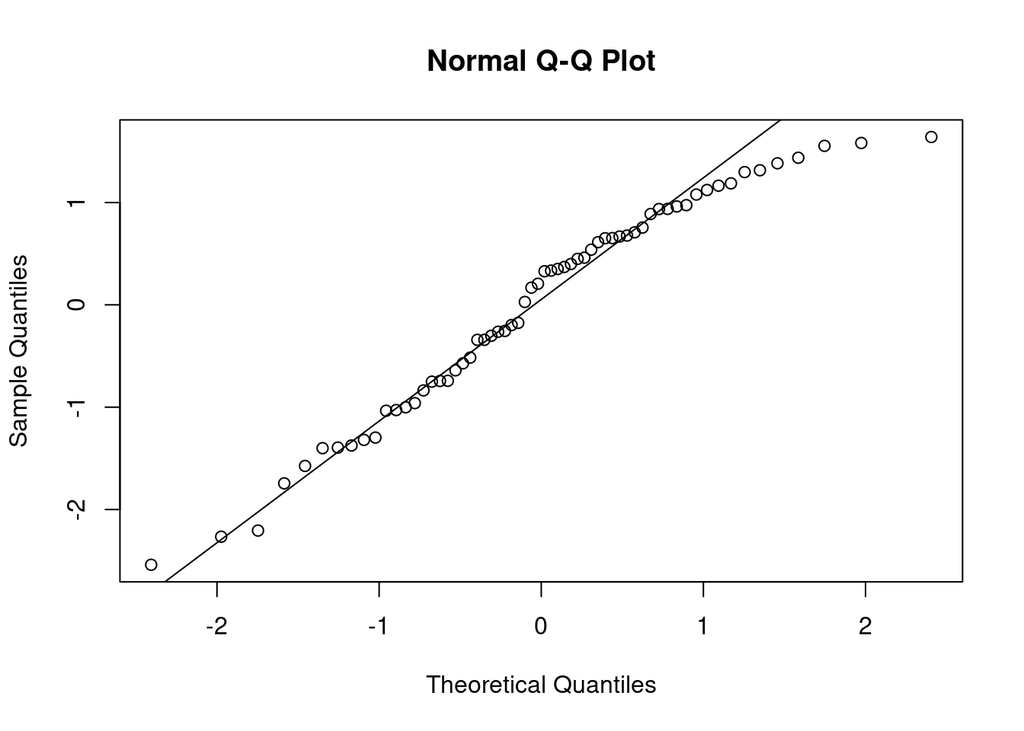

```r
qqnorm(residuals(model_bcnva))
qqline(residuals(model_bcnva))
```

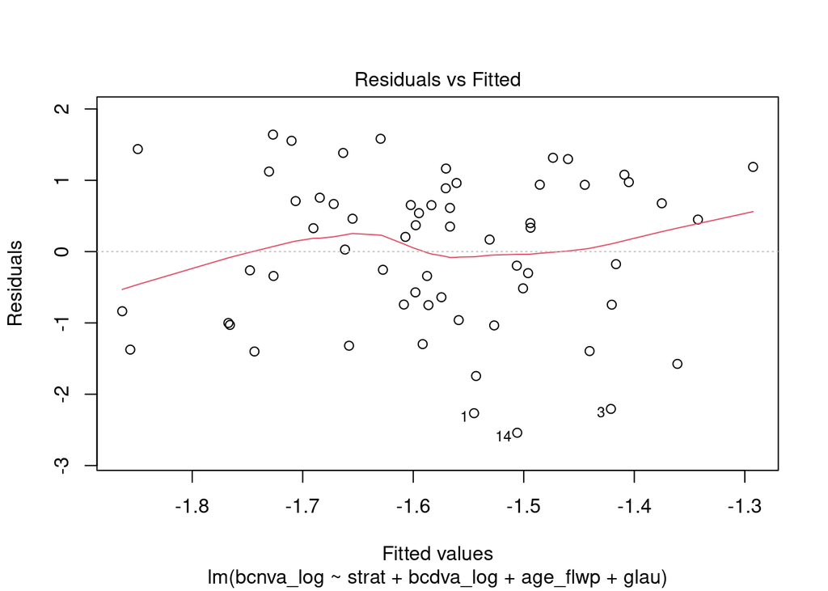

```r
plot(model_bcnva, which = 1)
```

```r
print(bptest(model_bcnva))
```

```
##
##  studentized Breusch-Pagan test
##
## data:  model_bcnva
## BP = 2.8876, df = 4, p-value = 0.5768
```

```r
print(shapiro.test(residuals(model_bcnva)))
```

```
##
##  Shapiro-Wilk normality test
##
## data:  residuals(model_bcnva)
## W = 0.95961, p-value = 0.0396
```

```r
# На границе 0.01 проходим предположение о нормальности, графически распределение адекватное
```

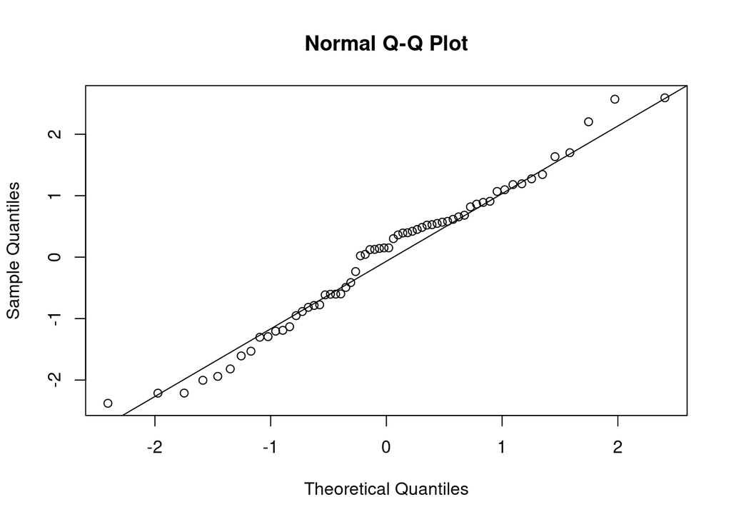

```r
qqnorm(residuals(model_bcdva))
qqline(residuals(model_bcdva))
```

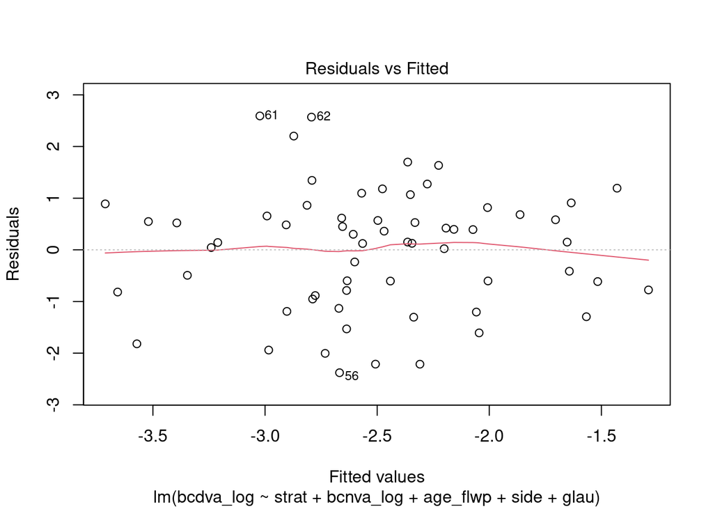

```r
plot(model_bcdva, which = 1)
```

```r
print(bptest(model_bcdva))
```

```
##
##  studentized Breusch-Pagan test
##
## data:  model_bcdva
## BP = 4.1758, df = 5, p-value = 0.5244
```

```r
print(shapiro.test(residuals(model_bcdva)))
```

```
##
##  Shapiro-Wilk normality test
##
## data:  residuals(model_bcdva)
## W = 0.978, p-value = 0.3287
```

```r
# Все тесты эта модель прошла
```

```r
summary(model_bcdva)
```

```
##
## Call:
## lm(formula = bcdva_log ~ strat + bcnva_log + age_flwp + side +
##     glau, data = df)
##
## Residuals:
##     Min      1Q  Median      3Q     Max
## -2.3782 -0.8090  0.1504  0.6755  2.5923
##
## Coefficients:
##                 Estimate Std. Error t value Pr(>|t|)
## (Intercept)      -1.0006     0.6986  -1.432   0.1576
## stratArtephakia   0.7749     0.3386   2.289   0.0259 *
## bcnva_log         0.1219     0.1472   0.828   0.4109
## age_flwp         -0.1236     0.0516  -2.396   0.0200 *
## sideR            -0.1820     0.3153  -0.577   0.5661
## glauYes          -0.5764     0.3215  -1.793   0.0783 .
## ---
## Signif. codes:  0 '***' 0.001 '**' 0.01 '*' 0.05 '.' 0.1 ' ' 1
##
## Residual standard error: 1.224 on 56 degrees of freedom
## Multiple R-squared:  0.1832, Adjusted R-squared:  0.1103
## F-statistic: 2.512 on 5 and 56 DF,  p-value: 0.04026
```

```r
anova(model_bcdva)
```

```
## Analysis of Variance Table
##
## Response: bcdva_log
##           Df Sum Sq Mean Sq F value  Pr(>F)
## strat      1  5.121  5.1210  3.4185 0.06975 .
## bcnva_log  1  1.094  1.0944  0.7305 0.39635
## age_flwp   1  7.498  7.4976  5.0050 0.02927 *
## side       1  0.286  0.2863  0.1911 0.66366
## glau       1  4.817  4.8168  3.2155 0.07835 .
## Residuals 56 83.889  1.4980
## ---
## Signif. codes:  0 '***' 0.001 '**' 0.01 '*' 0.05 '.' 0.1 ' ' 1
```

```r
summary(model_bcnva)
```

```
##
## Call:
## lm(formula = bcnva_log ~ strat + bcdva_log + age_flwp + glau,
##     data = df)
##
## Residuals:
##     Min      1Q  Median      3Q     Max
## -2.5399 -0.7489  0.2672  0.8547  1.6404
##
## Coefficients:
##                  Estimate Std. Error t value Pr(>|t|)
## (Intercept)     -1.491776   0.571440  -2.611   0.0115 *
## stratArtephakia  0.013544   0.316500   0.043   0.9660
## bcdva_log        0.098037   0.118505   0.827   0.4115
## age_flwp         0.012665   0.048220   0.263   0.7938
## glauYes          0.004951   0.294445   0.017   0.9866
## ---
## Signif. codes:  0 '***' 0.001 '**' 0.01 '*' 0.05 '.' 0.1 ' ' 1
##
## Residual standard error: 1.095 on 57 degrees of freedom
## Multiple R-squared:  0.01447,    Adjusted R-squared:  -0.05469
## F-statistic: 0.2093 on 4 and 57 DF,  p-value: 0.9323
```

```r
anova(model_bcnva)
```

```
## Analysis of Variance Table
##
## Response: bcnva_log
##           Df Sum Sq Mean Sq F value Pr(>F)
## strat      1  0.144 0.14445  0.1204 0.7298
## bcdva_log  1  0.776 0.77628  0.6473 0.4244
## age_flwp   1  0.083 0.08282  0.0691 0.7937
## glau       1  0.000 0.00034  0.0003 0.9866
## Residuals 57 68.362 1.19933
```

#### Анализ результатов моделирования

*Острота вдали.* 1. Качество модели. Модель отвечает предположениям о распределениях остатков. Признак глаукомы добавляет явное кол-во информации в модель, поскольку R квадрат повысился (18.32% вместе 13.63%, скорректированно 11.03% вместо 7.57%). Однако стоит отметить, что это все еще низкие значение, т.е. нам не хватает признаков для хорошего предсказания остроты зрения. 2. Наличие глаукомы значимо ухудшает зрение (p=0.0783), что подтверждает ANOVA(p=0.0784), на уровне значимости 0.1. 3. Стратегия лечения “Артефакия” все еще значимо положительно связана с остротой зрения вдали, более того в модели тест показывает значимость уже на уровне 0.05 (p=0.0259), что говорит о том, что этот показатель независим от наличия глаукомы, а также, что выравнивание на этот признак позволяет точнее описать зависимость стртегии от остроты зрения. 4. Возраст на фоллоу ап также остается значимой переменной, отрицательно коррелируя с остротой зрения вдали. 5. Остальные признаки также не влияют на остроту.

Т-тест для интерсепта незначим, т.е. при значении всех переменных равным 0, значение переменной скорее всего будет неотличным от 0.

*Острота вблизи* 1. Качество модели. Модель все еще плохо объясняет переменную и значение R квадрат не изменилось (1.447%) а скорректированное ожидаемо ухудшилось (-5.47% вместо -3.65%). Добавление признака глаукомы в модель не сделало ее эффективнее для объяснения изменений в остроте зрения вблизи. 2. Ни один из рассмотренных предикторов (наличие глаукомы, стратегия лечения, острота зрения вдали и возраст) также не оказывает значимого влияния на остроту зрения вблизи. Т.е. наличие глаукомы, видимо, несвязано с этим признаком. При значении всех переменных равным 0, значение переменной все еще остается значимо отличным от 0.

## 3. Как связана частота развития глаукомы с выбранной стратегией?

### 3.1. Оцените эффект стратегии без коррекции на ковариаты.

```r
con<-table(df$strat,df$glau)
con
```

```
##
##              No Yes
##   Aphakia    13  12
##   Artephakia 24  13
```

```r
# Можем применять хи-квадрат
```

```r
cross_tab <- table(df$strat, df$glau)
chi2_res <- chisq_test(cross_tab)
print(chi2_res)
```

```
## # A tibble: 1 × 6
##       n statistic     p    df method          p.signif
## * <int>     <dbl> <dbl> <int> <chr>           <chr>
## 1    62     0.561 0.454     1 Chi-square test ns
```

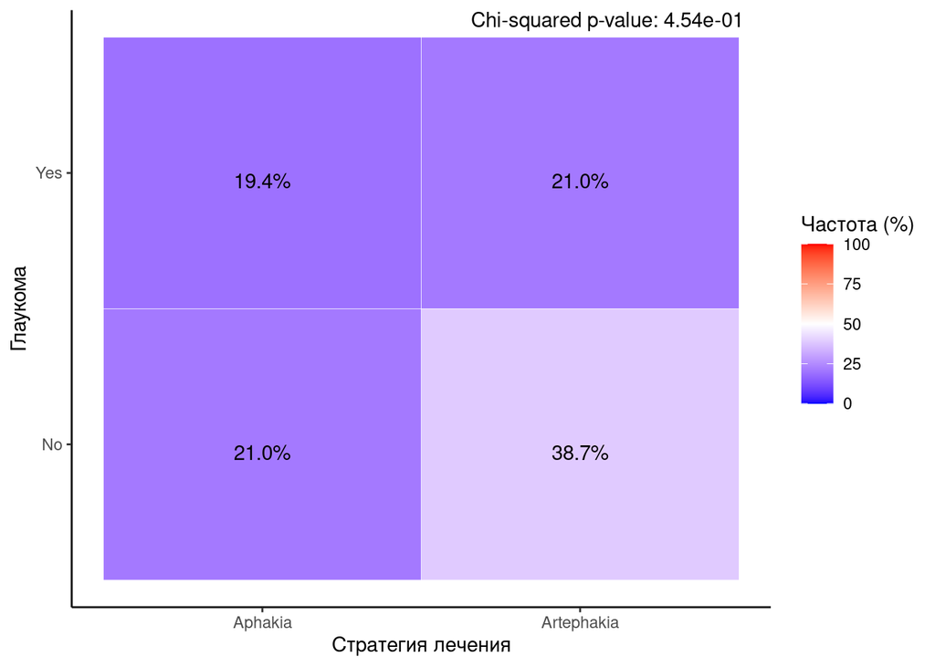

```r
cross_tab_df <- as.data.frame(as.table(cross_tab))
total_counts <- sum(cross_tab)
cross_tab_df$Freq <- cross_tab_df$Freq / total_counts * 100
ggplot(cross_tab_df, aes(Var1, Var2, fill = Freq)) +
  geom_tile(color = "white") +
  geom_text(aes(label = sprintf("%.1f%%", Freq)), vjust = 1) +
  scale_fill_gradient2(low = "blue", high = "red", mid = "white", midpoint = 50, limit = c(0,100), space = "Lab", name="Частота (%)") +
  theme_classic() +
  labs(x = "Стратегия лечения", y = "Глаукома") +
  annotate("text", x = Inf, y = Inf, label = paste("Chi-squared p-value:", formatC(chi2_res$p, format = "e", digits = 2)), hjust = 1.1, vjust = 1.1)
```

```r
# Значимой связи нет, визуально можно сказать, что больше пациентов без глаукомы попало в группу с лечением артефакией
```

### 3.2. Оцените эффект стратегии с коррекцией на ковариаты. Обоснуйте необходимость включения каждой ковариаты в вашу модель.

```r
library(glm2)

model_glau <- glm(glau ~ bcdva_log + strat + age_flwp, data = df, family = binomial())
print(vif(model_glau))
```

```
## bcdva_log     strat  age_flwp
##  1.173476  1.198905  1.259097
```

```r
#Включаю логарифмированную остроту зрения вдали, поскольку глаукома была для нее значимым паредиктором. Стратегию, поскольку это вопрос задачи. Возраст, поскольку он связан и со стратегией, и немного повышен у людей без глаукомы, судя по EDA.
```

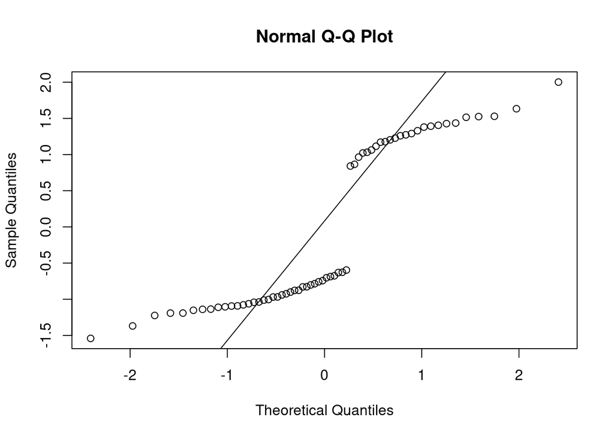

```r
qqnorm(residuals(model_glau))
qqline(residuals(model_glau))
```

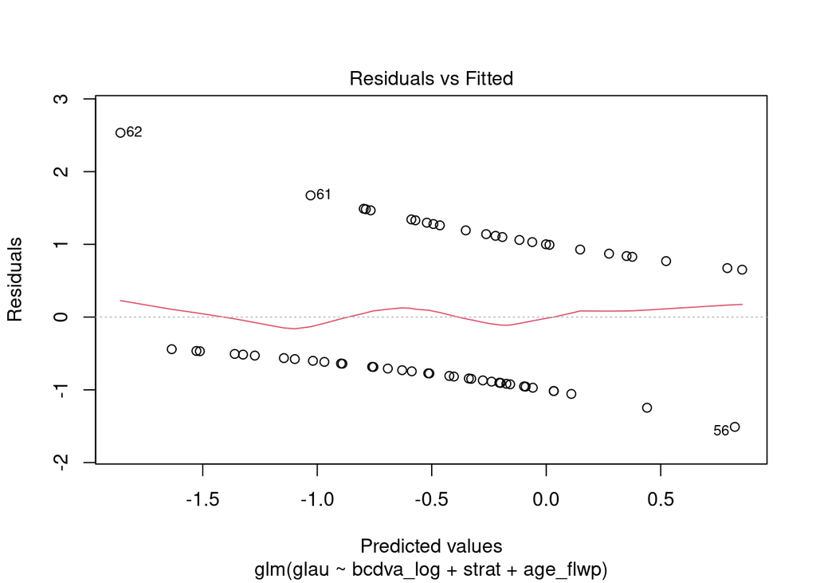

```r
plot(model_glau, which = 1)
```

```r
print(bptest(model_glau))
```

```
##
##  studentized Breusch-Pagan test
##
## data:  model_glau
## BP = 1.0906, df = 3, p-value = 0.7793
```

```r
print(shapiro.test(residuals(model_glau)))
```

```
##
##  Shapiro-Wilk normality test
##
## data:  residuals(model_glau)
## W = 0.79789, p-value = 8.364e-08
```

```r
# Остатки не распределены нормально, но это нормально, т.к. у нас лог регрессия
```

```r
summary(model_glau)
```

```
##
## Call:
## glm(formula = glau ~ bcdva_log + strat + age_flwp, family = binomial(),
##     data = df)
##
## Deviance Residuals:
##     Min       1Q   Median       3Q      Max
## -1.5411  -1.0312  -0.7229   1.1971   2.0021
##
## Coefficients:
##                 Estimate Std. Error z value Pr(>|z|)
## (Intercept)     -0.19773    1.05375  -0.188   0.8512
## bcdva_log       -0.41262    0.23309  -1.770   0.0767 .
## stratArtephakia -0.10617    0.59541  -0.178   0.8585
## age_flwp        -0.10297    0.09485  -1.086   0.2776
## ---
## Signif. codes:  0 '***' 0.001 '**' 0.01 '*' 0.05 '.' 0.1 ' ' 1
##
## (Dispersion parameter for binomial family taken to be 1)
##
##     Null deviance: 83.613  on 61  degrees of freedom
## Residual deviance: 78.913  on 58  degrees of freedom
## AIC: 86.913
##
## Number of Fisher Scoring iterations: 4
```

```r
base_model <- glm(glau ~ strat + age_flwp, data = df, family = binomial())

anova(base_model, model_glau, test = "LRT")
```

```
## Analysis of Deviance Table
##
## Model 1: glau ~ strat + age_flwp
## Model 2: glau ~ bcdva_log + strat + age_flwp
##   Resid. Df Resid. Dev Df Deviance Pr(>Chi)
## 1        59     82.262
## 2        58     78.913  1   3.3496  0.06722 .
## ---
## Signif. codes:  0 '***' 0.001 '**' 0.01 '*' 0.05 '.' 0.1 ' ' 1
```

```r
pred = as.factor(ifelse(predict(model_glau, type = "link") > 0, "Yes", "No"))
library(caret)
train_tab = table(predicted = pred, actual = df$glau)

train_con_mat = confusionMatrix(train_tab, positive = "Yes")
c(train_con_mat$overall["Accuracy"],
  train_con_mat$byClass["Sensitivity"],
  train_con_mat$byClass["Specificity"],
  train_con_mat$byClass["F1"])
```

```
##    Accuracy Sensitivity Specificity          F1
##   0.6451613   0.3200000   0.8648649   0.4210526
```

#### Анализ результатов моделирования

1. Качество модели низкое. Модель гораздо лучше идентифицирует отрицательные случаи, чем положительные. В целом, предсказательная способность модели очень низкая, как и в предыдущих случаях. 2.Единственным признаком, предсказывающим глаукому в модели оказалось зрение вдали на уровне значимости 0.1, что также подверждается сравнением моделей с помощью ANOVA.

Вывод: Стратегия лечения не связана с развитие глаукомы, судя по представленному анализу на данных.